# Natural Language Processing Example: Amazon Fine Food reviews

## Data discovery example

In this notebook, we will walk through the first steps in data discovery. It is a delightful process that aims to discover some information about the problem at hand (reviews in Amazon for food products), and feed our curiosity with some data and information, at the same time.

Some information has already been displayed from the dataset home page, but we will discover from actual data how to extract some of this information, and any other we could find useful.

## Load packages and data

The use of *pandas* package to handle data is nowadays a standard solution, due to the easiness of use (once its own language characteristics have been learnt), and efficiency.

At this point, data is already downloaded as a csv file from https://www.kaggle.com/snap/amazon-fine-food-reviews.

```python
%matplotlib inline

import re, time, pandas as pd
import matplotlib.pyplot as plt

# Start timing
t1 = time.time()

# We use pandas for loading and handling data for convenience
df = pd.read_csv('../data/amazon-fine-foods/Reviews.csv')
```

## Basic statistics

As we already know, the dataset is composed of:

- ProductId: Amazon product identifier (ASIN)
- UserId: Amazon internal user identifier
- ProfileName: Name of the user
- HelpfulnessNumerator: People which found it helpful
- HelpfulnessDenominator: People which expressed opinion
- Score: Product rating
- Time: Time of the review (Unix time)
- Summary: Review summary
- Text: Review text

Basic statistics taken from the home page are:

- Number of reviews: 568,454
- Number of users: 256,059
- Number of products: 74,258
- Users with more than 50 reviews: 260
- Median no. of words per review: 56
- Timespan: Oct 1999 - Oct 2012

```python
# Columns of the dataset, number of documents
print (df.columns, df.shape)
```

```
(Index([u'Id', u'ProductId', u'UserId', u'ProfileName', u'HelpfulnessNumerator',
       u'HelpfulnessDenominator', u'Score', u'Time', u'Summary', u'Text'],
      dtype='object'), (568454, 10))
```

```python
# Number of distinct users
print len(df['UserId'].unique())
```

```
256059
```

It is also interesting to just display a document for reference:

```python
# First document
print df.iloc[0,:]
```

```
Id                                                                        1
ProductId                                                        B001E4KFG0
UserId                                                       A3SGXH7AUHU8GW
ProfileName                                                      delmartian
HelpfulnessNumerator                                                      1
HelpfulnessDenominator                                                    1
Score                                                                     5
Time                                                             1303862400
Summary                                               Good Quality Dog Food
Text                      I have bought several of the Vitality canned d...
Name: 0, dtype: object
```

A question arises here: should I use the userId, the profile name... to address users? Data is usually not clean when just scraped or downloaded, and at this time, a single user could be referenced by different names along time. Let's feed our curiosity and learn if a user could change its profile name during this period, and if this feature has been used or not.

If a single user has two profile names, it means we cannot take profile names as unique identifiers for granted, and relations between userId and profile names are 1 to N relations. Therefore, we can assume only userId values for referencing users, and not profile names.

Otherwise, we could use both variables interchangeably, but userId is usually preferred as merging data using a string variable is usually highly inefficient.

```python
# Has any user changed its name? Display maximum number of profile names per user
df.groupby('UserId')['ProfileName'].nunique().max()
```

```
2
```

Another interesting question is review distribution, how many reviews a user usually inputs? Are there specially active users that write a lot of reviews? How many are "a lot"? For reference, the only data we already know about this is displayed here:

- Number of reviews: 568,454
- Number of users: 256,059
- Number of products: 74,258
- Users with more than 50 reviews: 260

Let's start creating a variable that holds the number of reviews per user, and summarizing the variable:

```python
nreviews = df.groupby('UserId')['Text'].count()
nreviews.describe()
```

```
count    256059.000000
mean          2.220012
std           4.443361
min           1.000000
25%           1.000000
50%           1.000000
75%           2.000000
max         448.000000
Name: Text, dtype: float64
```

From this description, we validated some of the values known beforehand (number of users, mean reviews per user...), but some hints of a "skewed" distribution arise here.

Firstly, most users (up to P50 at least) write only one review of a product, and many more (up to 75% at least) write two reviews at most. But, on the other hand, a single user wrote 448 reviews in this period! This is an example of skewness, and we could review the actual distribution with a histogram:

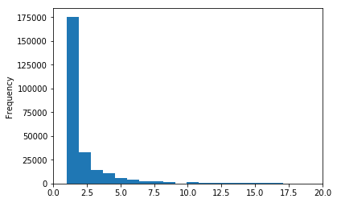

```python
nreviews.plot.hist(bins=500,xlim=(0,20))
```

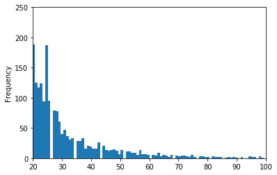

```python
nreviews.plot.hist(bins=500,xlim=(20,100),ylim=(0,250))
```

Had we started from any intermediate point in the number of reviews, and providing sufficient data and meaningful plotting scales, the distribution is similar. The fact that distribution is of low value for long ranges of x-values is known as 'long-tailed distribution', and can be found in most distributions concerning social behavior mechanisms, such as this one.

## Word distribution

A different interesting question arises about the inner structure of the reviews, which will be used in this problem for further discovery and solving some problems. A long-tailed distribution is expected, but what is the real distribution when considering word count in reviews?

We already knew that:

- Median no. of words per review: 56

, but what else could easily know? Let's solve this question:

```python
docs = df['Text'].apply(lambda x: x.split())
docs[:5]
```

```
0    [I, have, bought, several, of, the, Vitality, ...
1    [Product, arrived, labeled, as, Jumbo, Salted,...
2    [This, is, a, confection, that, has, been, aro...
3    [If, you, are, looking, for, the, secret, ingr...
4    [Great, taffy, at, a, great, price., There, wa...
Name: Text, dtype: object
```

```python
len_docs = docs.apply(lambda x: len(x))
len_docs[:5]
```

```
0    48
1    31
2    94
3    41
4    27
Name: Text, dtype: int64
```

```python
len_docs.describe()
```

```
count    568454.000000
mean         80.264023
std          79.455384
min           3.000000
25%          33.000000
50%          56.000000
75%          98.000000
max        3432.000000
Name: Text, dtype: float64
```

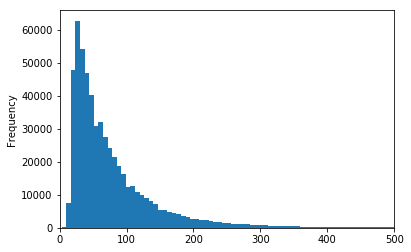

```python
len_docs.plot.hist(bins=500,xlim=(0,500))
```

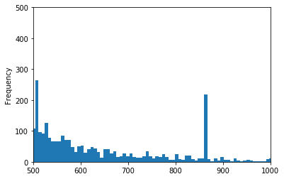

```python
len_docs.plot.hist(bins=500,xlim=(500,1000),ylim=(0,500))
```

## Ratings and helpfulness

It can be directly inferred that a variable such as 'Score' can easily be used for regression or ordinal classification problems. Therefore, it seems reasonable to discover some information about this variable, and two apriori related ones, 'HelpfulNominator' and 'HelpfulDenominator', which describe the usefulness or uselessness of a review.

Do these variables influence actual ratings? Products with no helpful or helpless reviews (just reviews) see their rating influenced?

Let's solve these questions:

```python
df['Score'].describe()
```

```
count    568454.000000
mean          4.183199
std           1.310436
min           1.000000
25%           4.000000
50%           5.000000
75%           5.000000
max           5.000000
Name: Score, dtype: float64
```

```python
df['HelpfulnessNumerator'].describe()
```

```
count    568454.000000
mean          1.743817
std           7.636513
min           0.000000
25%           0.000000
50%           0.000000
75%           2.000000
max         866.000000
Name: HelpfulnessNumerator, dtype: float64
```

```python
df['HelpfulnessDenominator'].describe()
```

```
count    568454.00000
mean          2.22881
std           8.28974
min           0.00000
25%           0.00000
50%           1.00000
75%           2.00000
max         923.00000
Name: HelpfulnessDenominator, dtype: float64
```

```python
# Another long-tailed distribution?
df['HelpfulnessDenominator'].value_counts()[:6]
```

```
0    270052
1    112753
2     61482
3     34394
4     22306
5     14824
Name: HelpfulnessDenominator, dtype: int64
```

To retrieve information about products with reviews not flagged as helpful or helpless by users, we first have to retrieve the list of these products, and then filter score by these products.

```python
prods_helpfulness = df.groupby('ProductId')['HelpfulnessDenominator'].sum()
prods_helpfulness = prods_helpfulness[prods_helpfulness==0].index.tolist()
(len(prods_helpfulness), prods_helpfulness[:5])
```

```
(24942, ['2841233731', '7800648702', '9376674501', 'B00002NCJC', 'B0000535LF'])
```

```python
prods_score = df.groupby('ProductId')['Score'].first()
prods_score[:5]
```

```
ProductId
0006641040    4
141278509X    5
2734888454    2
2841233731    5
7310172001    5
Name: Score, dtype: int64
```

```python
# Filter score for only those products with 0 helpful/helpless total count.
idx_prods_score = [i in prods_helpfulness for i in prods_score.index.values.tolist()]
prods_score = prods_score[idx_prods_score]
prods_score.value_counts()/len(prods_score)
```

```
5    0.681942
4    0.130262
1    0.074613
3    0.068158
2    0.045024
Name: Score, dtype: float64
```

```python
# Comparison with global score
df['Score'].value_counts()/len(df)
```

```
5    0.638789
4    0.141885
1    0.091948
3    0.075010
2    0.052368
Name: Score, dtype: float64
```

## Total time lapsed

```python
# Print total time lapsed
t2 = time.time()
print 'Time lapsed: {} seconds'.format(round(t2-t1,2))
```

```
Time lapsed: 47.37 seconds
```